# Salary: Pridicting salary difference

### In this assignment we are instructed to predict employee salaries from different employee characteristics or features. We asked employees working in four different fields to state their salary and some background information, and that information is stored in a csv file that we have to import in the jupyter notebook.

#### Then we start answering the questions provided.

```python
import numpy as np
import pandas as pd
import matplotlib.pyplot as plt
import seaborn as sns
%matplotlib inline
from scipy.stats import iqr
from scipy.stats.stats import pearsonr
```

```python
df1 = pd.read_excel("Salary metadata.xlsx")
df1.to_csv('salaryfile.csv', encoding='utf-8', index=False)
df1
```

|  | Variable | Type | Explanation |
| --- | --- | --- | --- |
| 0 | salary | Continuous | Annual salary in dollars |
| 1 | exprior | Continuous | Years of experience prior to working in this f... |
| 2 | yearsworked | Continuous | Years worked in this field |
| 3 | yearsrank | Continuous | Years worked at current rank |
| 4 | market | Continuous | Market value (1 = salary at market value for p... |
| 5 | degree | Binary | Has degree (0 = no, 1 = yes) |
| 6 | otherqual | Binary | Has other post-secondary qualification (0 = no... |
| 7 | position | Categorical | Position (1 = Junior Employee, 2 = Manager, 3 ... |
| 8 | male | Binary | 0 = no, 1 = yes |
| 9 | Field | Categorical | Field of work (1 = Engineering, 2 = Finance, 3... |
| 10 | yearsabs | Continuous | Years absent from work (e.g. due to illness / ... |

```python
#Making a dataframe and viewing summarised statistical values by calling DataFrame.describe()
df = pd.read_csv("salary.csv").dropna()
df.describe()
```

|  | salary | exprior | yearsworked | yearsrank | market | degree | otherqual | position | male | Field | yearsabs |
| --- | --- | --- | --- | --- | --- | --- | --- | --- | --- | --- | --- |
| count | 513.000000 | 513.000000 | 513.000000 | 513.000000 | 513.000000 | 513.000000 | 513.000000 | 513.000000 | 513.000000 | 513.000000 | 513.000000 |
| mean | 50863.220098 | 2.931774 | 12.836257 | 7.046784 | 0.948558 | 0.964912 | 0.044834 | 2.130604 | 0.750487 | 2.526316 | 6.994152 |
| std | 12685.132358 | 4.794327 | 9.447040 | 6.419708 | 0.149524 | 0.184181 | 0.207142 | 0.819977 | 0.433153 | 1.126644 | 16.887552 |
| min | 29000.000000 | 0.000000 | 0.000000 | 0.000000 | 0.710000 | 0.000000 | 0.000000 | 1.000000 | 0.000000 | 1.000000 | 0.000000 |
| 25% | 40000.000000 | 0.000000 | 4.000000 | 2.000000 | 0.840000 | 1.000000 | 0.000000 | 1.000000 | 1.000000 | 2.000000 | 0.000000 |
| 50% | 50096.000000 | 1.000000 | 12.000000 | 5.000000 | 0.920000 | 1.000000 | 0.000000 | 2.000000 | 1.000000 | 3.000000 | 1.000000 |
| 75% | 60345.000000 | 4.000000 | 22.000000 | 12.000000 | 1.020000 | 1.000000 | 0.000000 | 3.000000 | 1.000000 | 4.000000 | 2.000000 |
| max | 96156.000000 | 25.000000 | 41.000000 | 28.000000 | 1.330000 | 1.000000 | 1.000000 | 3.000000 | 1.000000 | 4.000000 | 118.000000 |

```python
#Call on DataFrame.info() to get an overview of the dataset we working with
df.info()
```

```
<class 'pandas.core.frame.DataFrame'>
Int64Index: 513 entries, 0 to 513
Data columns (total 11 columns):
salary         513 non-null float64
exprior        513 non-null int64
yearsworked    513 non-null int64
yearsrank      513 non-null int64
market         513 non-null float64
degree         513 non-null int64
otherqual      513 non-null int64
position       513 non-null int64
male           513 non-null int64
Field          513 non-null int64
yearsabs       513 non-null int64
dtypes: float64(2), int64(9)
memory usage: 48.1 KB
```

#### Q: a) How many responders are there? Are there any missing values in any of the variables?

```python
#Extrated the salary column from the summary statistics table.
print(df["salary"].describe())
```

```
count      513.000000
mean     50863.220098
std      12685.132358
min      29000.000000
25%      40000.000000
50%      50096.000000
75%      60345.000000
max      96156.000000
Name: salary, dtype: float64
```

#### Q: b) What is the lowest salary and highest salary in the group?

#### A: When looking at the summarised statistical values of the salary dataset we can look at the salary column and see that the lowest salary which is R29 000.00, and the highest is R96 156.00.

```python
#Calculation of Standard Error of the Mean
print(df["salary"].sem())
```

```
560.0622753925232
```

#### Q: c) What is the mean salary for the sample? Include the standard error of the mean.

#### A: Looking at the extracted salary column the mean = 50863.22 and we calculated the Standard Error Mean to be 560.062.

```python
#Extracted the Yearsworked column from the summary statistics table
print(df["yearsworked"].describe())
```

```
count    513.000000
mean      12.836257
std        9.447040
min        0.000000
25%        4.000000
50%       12.000000
75%       22.000000
max       41.000000
Name: yearsworked, dtype: float64
```

#### Q: d) What is the standard deviation for the years worked?

#### A: The standard deviation for the years worked is 9.447040.

```python
print(df["salary"].median())
```

```
50096.0
```

#### Q: e) What is the median salary for the sample?

#### A: Going back to the salary column we calculated the median to be 50096.0, the median is also the 2nd quatile range(Q2 = 50%).

```python
salary = df["salary"]
salary.sort_values()

print("The first quantile(Q1) is: ", salary.quantile(0.25))
print("The third quantile(Q3) is: ", salary.quantile(0.75))
print("The IQR = Q3 - Q1 = ", salary.quantile(0.75) - salary.quantile(0.25))
```

```
The first quantile(Q1) is:  40000.0
The third quantile(Q3) is:  60345.0
The IQR = Q3 - Q1 =  20345.0
```

#### Q: f) What is the interquartile range for salary in the sample?

#### A: I first sorted the column values in acsending order then calculated the Q1 and Q3, with the formula Q3 - Q1 we found the interquartile range(IQR) to be: IQR = 60345.0 - 40000.0 = 20345.0

```python
df['male'].value_counts()
```

```
1    385
0    128
Name: male, dtype: int64
```

#### Q: How many men are there in the sample? How many women are there in the sample? Present this information in a table.

| Male | Female |
| --- | --- |
| 385 | 128 |

```python
df['male'] =  df['male'].map({0: 'female', 1: 'male'})
df.groupby(['position', 'male']).size()
```

```
position  male
1         female     60
          male       83
2         female     49
          male      111
3         female     19
          male      191
dtype: int64
```

#### Q: How many women are executives compared to men?

#### A: According to the results we got they are 19 females who are executives compared to males who are 191, stating that they are few females in that high position.

#### Create a histogram for the variable Salary.

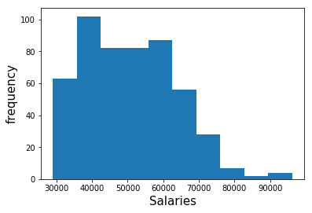

```python
_ = plt.hist(df["salary"])
_ = plt.ylabel('frequency', fontsize=15)
_ = plt.xlabel('Salaries', fontsize=15)

plt.show()
```

#### Q: Examine the histogram and describe the distribution for Salary.

#### A: The data is skewed to the right, meaning the average salary that people get is between 30000 and close to 80-85000.

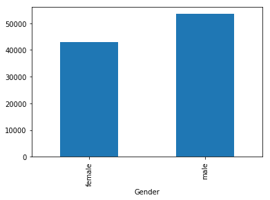

```python
a_salary = df.groupby('male').mean()
a_salary['salary'].plot(kind='bar')
plt.xlabel('Gender')
plt.show()
```

#### Q: Create a bar graph to show the different average salaries of men and women. (Bonus: Add error bars to the bars showing the 95% confidence interval). What does the graph tell you about the difference between men and women’s salaries?

#### A: The bar graph shows that males have higher salaries than females.

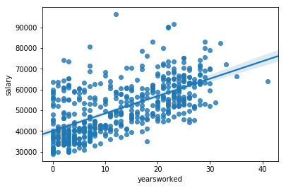

```python
sns.regplot(df["yearsworked"], df["salary"] )
```

#### Q: Create a scatterplot showing the relationship between Years Worked and Salary (don’t forget to insert a trend line). What is the relationship between Years Worked and Salary?

1. Describe any patterns in the scatterplot. Do you notice any unusual/extreme values that do not fit the general trend? If you see any unusual values, briefly describe them (Who are they? In what way are they different?)

#### A: The relationship between years worked and salary os positive. Looking at the plot we see that they are a few people who earn a lot of money with less years and some earn less money for a lot of years.

```python
#Looking at the correlation between the all the information given
df.corr()
```

|  | salary | exprior | yearsworked | yearsrank | market | degree | otherqual | position | Field | yearsabs |
| --- | --- | --- | --- | --- | --- | --- | --- | --- | --- | --- |
| salary | 1.000000 | 0.119989 | 0.623589 | 0.610706 | 0.407214 | 0.044554 | 0.167137 | 0.702122 | -0.499316 | -0.069630 |
| exprior | 0.119989 | 1.000000 | -0.245788 | -0.065893 | -0.035202 | -0.049165 | 0.264655 | 0.118031 | -0.046854 | 0.132022 |
| yearsworked | 0.623589 | -0.245788 | 1.000000 | 0.813456 | -0.070740 | 0.028122 | -0.040157 | 0.746311 | -0.264208 | 0.056113 |
| yearsrank | 0.610706 | -0.065893 | 0.813456 | 1.000000 | -0.026869 | 0.006347 | 0.007232 | 0.484891 | -0.265620 | 0.035962 |
| market | 0.407214 | -0.035202 | -0.070740 | -0.026869 | 1.000000 | 0.036456 | 0.021641 | -0.013116 | -0.223887 | -0.167177 |
| degree | 0.044554 | -0.049165 | 0.028122 | 0.006347 | 0.036456 | 1.000000 | -0.214654 | 0.043335 | -0.099077 | 0.029447 |
| otherqual | 0.167137 | 0.264655 | -0.040157 | 0.007232 | 0.021641 | -0.214654 | 1.000000 | 0.160941 | -0.076202 | -0.017792 |
| position | 0.702122 | 0.118031 | 0.746311 | 0.484891 | -0.013116 | 0.043335 | 0.160941 | 1.000000 | -0.292313 | 0.030521 |
| Field | -0.499316 | -0.046854 | -0.264208 | -0.265620 | -0.223887 | -0.099077 | -0.076202 | -0.292313 | 1.000000 | 0.000778 |
| yearsabs | -0.069630 | 0.132022 | 0.056113 | 0.035962 | -0.167177 | 0.029447 | -0.017792 | 0.030521 | 0.000778 | 1.000000 |

```python
pearsonr(df['salary'],df['yearsworked'])
```

```
(0.6235888657598045, 1.2873351342921916e-56)
```

#### Q: Using the pearsonr function from the scipy.stats package, calculate the Pearson correlation coefficient (and its corresponding p value) to determine the nature of the relationship between Years Worked and Salary. See help(pearsonr) for help on this function.

1. Interpret the size and direction of the correlation statistic.
2. Is the relationship statistically significant? Report the appropriate statistic(s) to support your answer.